# genetic_drift

Week 11: Genetic drift and simulating the Buri experiment

```python
import numpy as np
import numba
import random
import matplotlib.pyplot as plt
import scipy.integrate

import seaborn as sns
sns.set(font_scale = 1.5, rc={"lines.linewidth":2})
```

Simulating a single vial of a Buri experiment

Let's simulate how a single vial might drift over time in the Buri experiment. We will first initialize some parameters:

```python
# number of flies in each vial
n_flies = 16

# number of generations to run the simulation
n_generations = 20

# initilaize an array to store the frequency of the red allele
r_freq = np.zeros(n_generations)
r_freq[0] = 0.5
```

How will the allele frequency change over time for our vial? Using the "bag of alleles" approximation, we will draw the next generation's 32 alleles, each with a 0.5 chance of being red. For this we can use np.random.binomial(n, p), where n will be the number of alleles we want and p will be the probability of grabbing a red allele out of our "bag".

As an example:

```python
n = n_flies * 2
p = 0.5

# how many red alleles do we get?
np.random.binomial(n, p)
```

```
16
```

If you run that cell repeatedly, you'll see that the average result will be that 16 alleles will be red, but this value can vary.

Using this approach for generating the next generation's red allele frequency, let's simulate a single vial over time, updating the frequency at each generation:

```python
for i in range(1, n_generations):
    p = r_freq[i-1]
    num_red = np.random.binomial(n_flies*2, p)
    new_r_freq = num_red / (n_flies*2)
    r_freq[i] = new_r_freq

r_freq
```

```
array([0.5    , 0.375  , 0.5    , 0.40625, 0.5625 , 0.59375, 0.625  ,
       0.65625, 0.59375, 0.65625, 0.6875 , 0.53125, 0.5625 , 0.6875 ,
       0.65625, 0.65625, 0.65625, 0.59375, 0.5    , 0.5625 ])
```

Plotting the results. Does the red or white allele become fixed?

```
(0.0, 1.0)
```

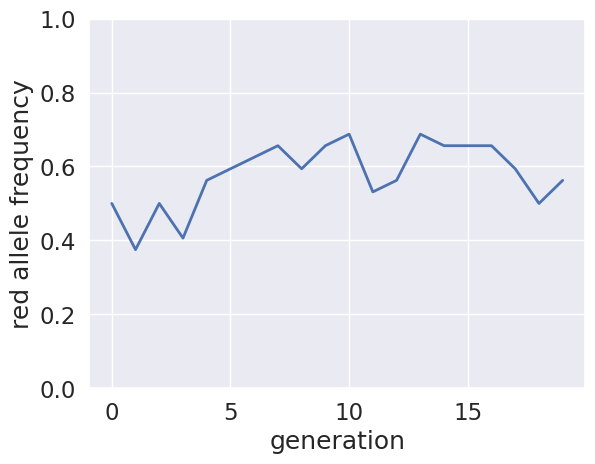

```python
plt.plot(r_freq)
plt.xlabel("generation")
plt.ylabel("red allele frequency")
plt.ylim([0,1])
```

Problem 1 -- Simulating the full Buri experiment

Extend what we've done so far to model the entire Buri experiment, tracking 107 vials over 20 generations. For this, we will want to use a 2D-array, such as red_freq = np.zeros([n_vials, n_generations]) to store our allele frequencies in.

Problem 2 -- Modifying the population size

Rerun your simulation for n_flies = 8 and n_flies = 32 and plot your results. From your results, how do population size and genetic drift relate?

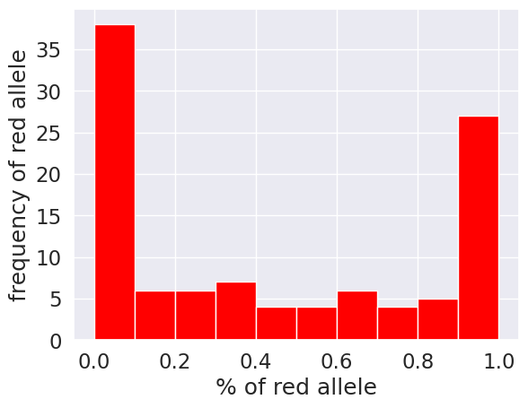

```python
n_flies = 8

n_vials = 107

n_generations = 20

red_freq = np.zeros([n_vials, n_generations])

n = n_flies * 2



for i in range(0, n_vials):

    red_freq[i,0] = 0.5

    for x in range (1, n_generations):

        p = red_freq[i, x-1]

        num_red = np.random.binomial(n_flies*2, p)

        new_r_freq = num_red / (n_flies * 2)

        red_freq[i, x] = new_r_freq

red_freq

plt.hist(red_freq[:,-1], color="red")

plt.xlabel("% of red allele")

plt.ylabel("frequency of red allele")
```

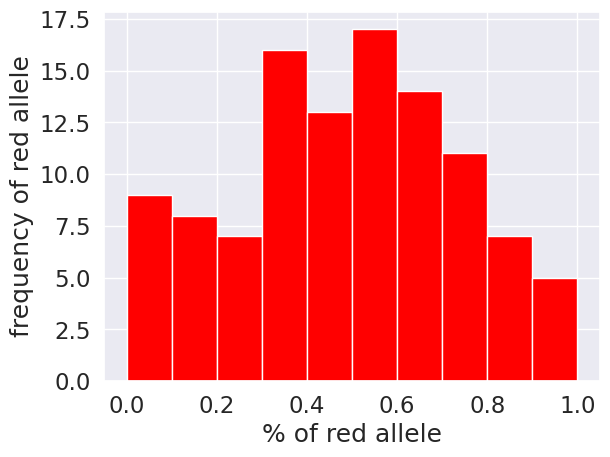

```python
n_flies = 32

n_vials = 107

n_generations = 20

red_freq = np.zeros([n_vials, n_generations])

n = n_flies * 2

for i in range(0, n_vials):

    red_freq[i,0] = 0.5

    for x in range (1, n_generations):

        p = red_freq[i, x-1]

        num_red = np.random.binomial(n_flies*2, p)

        new_r_freq = num_red / (n_flies * 2)

        red_freq[i, x] = new_r_freq

red_freq

plt.hist(red_freq[:,-1], color="red")

plt.xlabel("% of red allele")

plt.ylabel("frequency of red allele")
```

Increase in Population size decreases the effect of genetic drift. Vice versa is true, with genetic drift being more pronounced in small populations.

Problem 3 -- Modifying the number of generations

Returning to n_flies = 16, run the simulation for 100 generations and plot your results. From your results, what role does time seem to play in genetic drift?

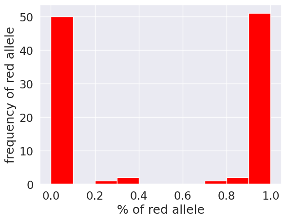

```python
n_flies = 16

n_vials = 107

n_generations = 100

red_freq = np.zeros([n_vials, n_generations])

n = n_flies * 2

for i in range(0, n_vials):

    red_freq[i,0] = 0.5

    for x in range (1, n_generations):

        p = red_freq[i, x-1]

        num_red = np.random.binomial(n_flies*2, p)

        new_r_freq = num_red / (n_flies * 2)

        red_freq[i, x] = new_r_freq

red_freq

plt.hist(red_freq[:,-1], color="red")

plt.xlabel("% of red allele")

plt.ylabel("frequency of red allele")
```

Time makes geentic drift more pronounced as susbequent generations amplify the expression or lack of expression of the red allele.

Grade: 20/20